# Call Stata from Python

### Zhao Xu

##### Principal Software Engineer StataCorp LLC

##### July 16, 2021

## Outline

- Introduction
- How it works
- Configuration and initialization
- Call Stata using magic commands
  - The stata magic
  - The mata magic
  - The pystata magic
- Call Stata using API functions
- Summary
- Addition resources

## Introduction

Stata provides a tight integration with Python named **PyStata**. It contains two parts:

- In Stata 16, we introduced **PyStata integration** allowing users to call Python from Stata:
  - Invode Python code interactively
  - Embed Python code in do-files and ado-files
  - Run Python script files (**.py**) from within Stata
- In Stata 17, we introduced **PyStata module** allowing users to call Stata from Python:
  - Access Stata and Mata conveniently in an IPython (interactive Python) kernel-based environment, such as Jupyter Notebook and console, JupyterLab and console
  - Call Stata and Mata from environments that support the IPython kernel, such as Spyder IDE and PyCharm IDE
  - Call Stata and Mata when accessing Python from command-line environments, such as Window Command Prompt, masOS terminal, and Unix terminal

## How it works

The **pystata** Python package includes two sets of tools for interacting with Stata from Python:

- IPython magic commands
  - **%%stata** and **%stata**
  - **%%mata** and **%mata**
  - **%pystata**
- A suite of API functions
  - The **stata** module
  - The **config** module

The magic commands can be used to access Stata and Mata interactively in an IPython kernel-based environment. The API functions can be used to interact with Stata and Mata from both IPython and command-line environments.

## Configuration and initialization

The **pystata** package is shipped with Stata and is located in **STATA_SYSDIR/utilities/pystata** directory. To get started, we need to configure the **pystata** package within Python to initialize Stata.

There are [four methods](https://www.stata.com/python/pystata/install.html#method-1-installing-via-pip) to initialize Stata from within Python. In the first method, the configuration module [stata_setup](https://pypi.org/project/stata-setup/), which is available in the Python Package Index (PyPI), is provided to locate the pystata package to initialize Stata.

Suppose we have Stata installed in **C:/Program Files/Stata17/** and we use the **Stata/MP** edition. Stata can be initialized as follows:

```python
import stata_setup
stata_setup.config("C:/Program Files/Stata17/", "mp")
```

```
  ___  ____  ____  ____  ____ ©
 /__    /   ____/   /   ____/      17.0
___/   /   /___/   /   /___/       MP—Parallel Edition

 Statistics and Data Science       Copyright 1985-2021 StataCorp LLC
                                   StataCorp
                                   4905 Lakeway Drive
                                   College Station, Texas 77845 USA
                                   800-STATA-PC        https://www.stata.com
                                   979-696-4600        stata@stata.com

Stata license: Single-user 8-core  perpetual
Serial number: 100
  Licensed to: zxx
               StataCorp LLC

Notes:
      1. Unicode is supported; see help unicode_advice.
      2. More than 2 billion observations are allowed; see help obs_advice.
      3. Maximum number of variables is set to 5,000; see help set_maxvar.
```

## Call Stata using magic commands

The **pystata** package provides three magic commands to interact with Stata from within the IPython environment:

- **stata**: Execute Stata commands
- **mata**: Execute Mata code
- **pystata**: Configure and display current system information

### The stata magic

The **stata** magic can be used as both a cell magic and a line magic to execute Stata commands.

```python
%%stata?
```

Execute one line or a block of Stata commands.

When the line magic command **%stata** is used, a one-line Stata command can be specified and executed, as it would be in Stata's Command window. When the cell magic command **%%stata** is used, a block of Stata commands can be specified and executed all at once. This is similar to executing a series of commands from a do-file.

Cell magic syntax:

```
%%stata [-d DATA] [-f DFLIST|ARRLIST] [-force]
 [-doutd DATAFRAME] [-douta ARRAY] [-foutd FRAMELIST] [-fouta FRAMELIST]
 [-ret DICTIONARY] [-eret DICTIONARY] [-sret DICTIONARY] [-qui] [-nogr]
 [-gw WIDTH] [-gh HEIGHT]

Optional arguments:

  -d DATA               Load a NumPy array or pandas DataFrame
                        into Stata as the current working dataset.

  -f DFLIST|ARRLIST     Load one or multiple NumPy arrays or
                        pandas DataFrames into Stata as frames.
                        The arrays and dataframes should be
                        separated by commas. Each array or
                        DataFrame is stored in Stata as a separate
                        frame with the same name.

  -force                Force loading of the NumPy array or pandas
                        DataFrame into Stata as the current working
                        dataset, even if the dataset in memory has
                        changed since it was last saved; or force
                        loading of the NumPy arrays or pandas DataFrames
                        into Stata as separate frames even if one or
                        more of the frames already exist in Stata.

  -doutd DATAFRAME      Save the dataset in memory as a pandas
                        DataFrame when the cell completes.

  -douta ARRAY          Save the dataset in memory as a NumPy
                        array when the cell completes.

  -foutd FRAMELIST      Save one or multiple Stata frames as pandas
                        DataFrames when the cell completes. The Stata
                        frames should be separated by commas. Each
                        frame is stored in Python as a pandas
                        DataFrame. The variable names in each frame
                        will be used as the column names in the
                        corresponding dataframe.

  -fouta FRAMELIST      Save one or multiple Stata frames as NumPy
                        arrays when the cell completes. The Stata frames
                        should be separated by commas. Each frame is
                        stored in Python as a NumPy array.

  -ret DICTIONARY       Store current r() results into a dictionary.

  -eret DICTIONARY      Store current e() results into a dictionary.

  -sret DICTIONARY      Store current s() results into a dictionary.

  -qui                  Run Stata commands but suppress output.

  -nogr                 Do not display Stata graphics.

  -gw WIDTH             Set graph width in inches, pixels, or centimeters;
                        default is inches.

  -gh HEIGHT            Set graph height in inches, pixels, or centimeters;
                        default is inches.
```

Line magic syntax:

```
%stata stata_cmd
```

### %%stata cell magic

The **%%stata** magic is used to execute Stata code within a cell.

```python
%%stata
sysuse auto, clear
describe
```

```
. sysuse auto, clear
(1978 automobile data)

. describe

Contains data from C:\Program Files\Stata17/ado\base/a/auto.dta
 Observations:            74                  1978 automobile data
    Variables:            12                  13 Apr 2020 17:45
                                              (_dta has notes)
-------------------------------------------------------------------------------
Variable      Storage   Display    Value
    name         type    format    label      Variable label
-------------------------------------------------------------------------------
make            str18   %-18s                 Make and model
price           int     %8.0gc                Price
mpg             int     %8.0g                 Mileage (mpg)
rep78           int     %8.0g                 Repair record 1978
headroom        float   %6.1f                 Headroom (in.)
trunk           int     %8.0g                 Trunk space (cu. ft.)
weight          int     %8.0gc                Weight (lbs.)
length          int     %8.0g                 Length (in.)
turn            int     %8.0g                 Turn circle (ft.)
displacement    int     %8.0g                 Displacement (cu. in.)
gear_ratio      float   %6.2f                 Gear ratio
foreign         byte    %8.0g      origin     Car origin
-------------------------------------------------------------------------------
Sorted by: foreign

.
```

```python
%%stata
scatter mpg weight, by(foreign, total)
```

[figure not shown]

### %stata line magic

The **%stata** magic provides users a quick way to execute a single-line Stata command.

```python
%stata summarize mpg
```

```
    Variable |        Obs        Mean    Std. dev.       Min        Max
-------------+---------------------------------------------------------
         mpg |         74     21.2973    5.785503         12         41
```

### Arguments

The cell magic **%%stata** provides arguments to control the execution of Stata’s commands within the cell.

```python
%%stata -qui
summarize mpg
```

```python
%%stata -gw 12cm
scatter mpg weight, by(foreign, total)
```

[figure not shown]

### Load dataset from Python

There are many ways to load data from Python into Stata's current dataset in memory. For example

1. pandas DataFrames and Numpy arrays can be loaded directly into Stata.
2. The **Data** and **Frame** classes within the **Stata Function Interface (sfi)** module provide multiple methods for loading data from Python.
3. Stata can read in data from a variety of sources, many of which can be created in Python: Excel files, CSV files, SPSS and SAS dataset, and various databases.

We have data from the **Second National Health and Nutrition Examination Survey** (**NHANES II**; [McDowell et al. 1981](https://pubmed.ncbi.nlm.nih.gov/7344293/)) studying the health and nutritional status of adults and children between 1976 and 1980. We want to use Stata’s features to fit a regression model of **bpsystol** as a function of age group (**agegrp**) and **gender**. Then we want to see how the average predicted systolic blood pressure varies across individuals in each age group, and across males and females in each age group.

```python
import pandas as pd
import io
import requests

data = requests.get("https://www.stata.com/python/pystata/misc/nhanes2.csv").content
nhanes2 = pd.read_csv(io.StringIO(data.decode('utf-8')))
nhanes2
```

|  | sampl | strata | psu | region | smsa | location | houssiz | sex | race | age | ... | region4 | smsa1 | smsa2 | smsa3 | rural | loglead | agegrp | highlead | bmi | highbp |
| --- | --- | --- | --- | --- | --- | --- | --- | --- | --- | --- | --- | --- | --- | --- | --- | --- | --- | --- | --- | --- | --- |
| 0 | 1400 | 1 | 1 | S | 2 | 1 | 4 | Male | White | 54 | ... | 0 | 0 | 1 | 0 | 0 | NaN | 50-59 | NaN | 20.495686 | 0 |
| 1 | 1401 | 1 | 1 | S | 2 | 1 | 6 | Female | White | 41 | ... | 0 | 0 | 1 | 0 | 0 | 2.564949 | 40-49 | lead<25 | 21.022337 | 0 |
| 2 | 1402 | 1 | 1 | S | 1 | 1 | 6 | Female | Other | 21 | ... | 0 | 1 | 0 | 0 | 0 | NaN | 20-29 | NaN | 24.973860 | 0 |
| 3 | 1404 | 1 | 1 | S | 2 | 1 | 9 | Female | White | 63 | ... | 0 | 0 | 1 | 0 | 0 | NaN | 60-69 | NaN | 35.728722 | 1 |
| 4 | 1405 | 1 | 1 | S | 1 | 1 | 3 | Female | White | 64 | ... | 0 | 1 | 0 | 0 | 0 | 2.995732 | 60-69 | lead<25 | 27.923803 | 0 |
| ... | ... | ... | ... | ... | ... | ... | ... | ... | ... | ... | ... | ... | ... | ... | ... | ... | ... | ... | ... | ... | ... |
| 10346 | 48760 | 32 | 2 | MW | 4 | 48 | 5 | Female | White | 35 | ... | 0 | 0 | 0 | 1 | 1 | NaN | 30-39 | NaN | 20.355173 | 0 |
| 10347 | 48763 | 32 | 2 | MW | 4 | 48 | 2 | Female | White | 33 | ... | 0 | 0 | 0 | 1 | 1 | 1.945910 | 30-39 | lead<25 | 41.645557 | 1 |
| 10348 | 48764 | 32 | 2 | MW | 4 | 48 | 1 | Female | White | 60 | ... | 0 | 0 | 0 | 1 | 0 | NaN | 60-69 | NaN | 35.626114 | 0 |
| 10349 | 48768 | 32 | 2 | MW | 4 | 48 | 1 | Female | White | 29 | ... | 0 | 0 | 0 | 1 | 0 | NaN | 20-29 | NaN | 19.204464 | 0 |
| 10350 | 48770 | 32 | 2 | MW | 4 | 48 | 1 | Male | White | 31 | ... | 0 | 0 | 0 | 1 | 1 | NaN | 30-39 | NaN | 19.635565 | 0 |

10351 rows × 58 columns

We use the **-d** argument to load the DataFrame into Stata as current dataset. Within Stata, we encode **agegrp** and **sex** and label the resulting variables, **agegrp2** and **sex2**, along with **bpsystol**.

```python
%%stata -d nhanes2 -force
label define sex2 1 "Male" 2 "Female"
encode sex, generate(sex2) label(sex2)

label define agegrp 1 "20-29" 2 "30-39" 3 "40-49" 4 "50-59" 5 "60-69" 6 "70+"
encode agegrp, generate(agegrp2) label(agegrp)

label variable bpsystol "systolic blood pressure"
label variable agegrp2 "Age Group"
label variable sex2 "1=Male, 2=Female"

describe bpsystol agegrp2 sex2
```

```
. label define sex2 1 "Male" 2 "Female"

. encode sex, generate(sex2) label(sex2)

.
. label define agegrp 1 "20-29" 2 "30-39" 3 "40-49" 4 "50-59" 5 "60-69" 6 "70+"

. encode agegrp, generate(agegrp2) label(agegrp)

.
. label variable bpsystol "systolic blood pressure"

. label variable agegrp2 "Age Group"

. label variable sex2 "1=Male, 2=Female"

.
. describe bpsystol agegrp2 sex2

Variable      Storage   Display    Value
    name         type    format    label      Variable label
-------------------------------------------------------------------------------
bpsystol        long    %12.0g                systolic blood pressure
agegrp2         long    %8.0g      agegrp     Age Group
sex2            long    %8.0g      sex2       1=Male, 2=Female

.
```

Next, we fit the model and push Stata's estimation results into Python. The estimation results are stored in **steret**, which is a Python dictionary.

```python
%%stata -eret steret
// fit a regression model
regress bpsystol agegrp2##sex2

// e() results
ereturn list
```

```
. // fit a regression model
. regress bpsystol agegrp2##sex2

      Source |       SS           df       MS      Number of obs   =    10,351
-------------+----------------------------------   F(11, 10339)    =    312.88
       Model |  1407229.28        11  127929.935   Prob > F        =    0.0000
    Residual |  4227440.75    10,339  408.882943   R-squared       =    0.2497
-------------+----------------------------------   Adj R-squared   =    0.2489
       Total |  5634670.03    10,350  544.412563   Root MSE        =    20.221

------------------------------------------------------------------------------
    bpsystol | Coefficient  Std. err.      t    P>|t|     [95% conf. interval]
-------------+----------------------------------------------------------------
     agegrp2 |
      30-39  |   .7956175   .9473117     0.84   0.401    -1.061297    2.652532
      40-49  |   5.117078   1.018176     5.03   0.000     3.121256      7.1129
      50-59  |   12.20018   1.022541    11.93   0.000      10.1958    14.20456
      60-69  |   16.85887   .8155092    20.67   0.000     15.26031    18.45742
        70+  |   22.50889   1.130959    19.90   0.000     20.29199    24.72579
        sex2 |
     Female  |  -12.60132   .8402299   -15.00   0.000    -14.24833    -10.9543
agegrp2#sex2 |
      30-39 #|
     Female  |   4.140156    1.31031     3.16   0.002     1.571695    6.708617
      40-49 #|
     Female  |   8.644866   1.412067     6.12   0.000     5.876941    11.41279
      50-59 #|
     Female  |   11.83134   1.406641     8.41   0.000     9.074051    14.58863
      60-69 #|
     Female  |     14.093   1.130882    12.46   0.000     11.87625    16.30975
 70+#Female  |   15.86608   1.542296    10.29   0.000     12.84288    18.88928
       _cons |   123.8862   .6052954   204.67   0.000     122.6997    125.0727
------------------------------------------------------------------------------

.
. // e() results
. ereturn list

scalars:
                  e(N) =  10351
```

[output cut: 17 more lines]

```
             e(depvar) : "bpsystol"
                e(cmd) : "regress"
         e(properties) : "b V"
            e(predict) : "regres_p"
              e(model) : "ols"
          e(estat_cmd) : "regress_estat"

matrices:
                  e(b) :  1 x 21
                  e(V) :  21 x 21

functions:
             e(sample)

.
```

```python
steret.keys()
```

```
dict_keys(['e(N)', 'e(df_m)', 'e(df_r)', 'e(F)', 'e(r2)', 'e(rmse)', 'e(mss)', 'e(rss)', 'e(r2_a)', 'e(ll)', 'e(ll_0)', 'e(rank)', 'e(cmdline)', 'e(title)', 'e(marginsprop)', 'e(marginsok)', 'e(vce)', 'e(depvar)', 'e(cmd)', 'e(properties)', 'e(predict)', 'e(model)', 'e(estat_cmd)', 'e(b)', 'e(V)'])
```

You can access specific elements of the dictionary. For example, you can access **e(b)** and **e(V)** by typing **steret['e(b)']** and **steret['e(V)']** in Python.

```python
steret['e(b)']
```

```
array([[  0.        ,   0.79561746,   5.11707797,  12.20017802,
         16.85886868,  22.50888857,   0.        , -12.601317  ,
          0.        ,   0.        ,   0.        ,   4.14015609,
          0.        ,   8.6448661 ,   0.        ,  11.83133884,
          0.        ,  14.09300146,   0.        ,  15.86607901,
        123.88620072]])
```

### Push Stata dataset into Python

The *iris* dataset consists of four features measured on 50 samples from each of three Iris species. This data is used in Fisher's (1936) article.

```python
%%stata
use http://www.stata-press.com/data/r17/iris, clear
describe
label list species
```

```
. use http://www.stata-press.com/data/r17/iris, clear
(Iris data)

. describe

Contains data from http://www.stata-press.com/data/r17/iris.dta
 Observations:           150                  Iris data
    Variables:             5                  18 Jan 2020 13:23
                                              (_dta has notes)
-------------------------------------------------------------------------------
Variable      Storage   Display    Value
    name         type    format    label      Variable label
-------------------------------------------------------------------------------
iris            byte    %10.0g     species    Iris species
seplen          double  %4.1f                 Sepal length in cm
sepwid          double  %4.1f                 Sepal width in cm
petlen          double  %4.1f                 Petal length in cm
petwid          double  %4.1f                 Petal width in cm
-------------------------------------------------------------------------------
Sorted by:

. label list species
species:
           1 setosa
           2 versicolor
           3 virginica

.
```

Our goal is to build a classifier using those four features to detect the Iris type. We will use the **Random Forest** classification model within the **scikit-learn** Python package to achieve this goal.

```python
%%stata -fouta training,test
// Split the original dataset into training and test
// dataset which contains 80% and 20% of observations respectively
splitsample, generate(svar, replace) split(0.8 0.2) show rseed(16)

// create two frames holding the the two datasets
frame put iris seplen sepwid petlen petwid if svar==1, into(training)
frame put iris seplen sepwid petlen petwid if svar==2, into(test)
```

```
. // Split the original dataset into training and test
. // dataset which contains 80% and 20% of observations respectively
. splitsample, generate(svar, replace) split(0.8 0.2) show rseed(16)

       svar |      Freq.     Percent        Cum.
------------+-----------------------------------
          1 |        120       80.00       80.00
          2 |         30       20.00      100.00
------------+-----------------------------------
      Total |        150      100.00

.
. // create two frames holding the the two datasets
. frame put iris seplen sepwid petlen petwid if svar==1, into(training)

. frame put iris seplen sepwid petlen petwid if svar==2, into(test)

.
```

Now we have 2 NumPy arrays in Python, **training** and **test**. Below we split each array into two sub-arrays to store the features and labels separately.

```python
X_train = training[:, 1:]
y_train = training[:, 0]
X_test = test[:, 1:]
y_test = test[:, 0]
```

Then we use **X_train** and **y_train** to train the classification model.

```python
from sklearn.ensemble import RandomForestClassifier

clf = RandomForestClassifier(max_depth=3, random_state=17)
clf.fit(X_train, y_train)
```

```
RandomForestClassifier(max_depth=3, random_state=17)
```

Next we use **X_test** and **y_test** to evaluate the performace of the training model. We also predict the species type of each flower and the probabilities that it belongs to the three species in the test dataset.

```python
from sklearn import metrics

y_pred = clf.predict(X_test)
y_pred_prob = clf.predict_proba(X_test)
```

Next, in the **test** frame, we create a Byte variable **irispr** to store the predicted species types and three float variables to store the probabilities that each flower belongs to the three species types from the array **y_pred_prob**.

```python
from sfi import Frame

fr = Frame.connect('test')
fr.addVarByte('irispr')
fr.addVarFloat('pr1')
fr.addVarFloat('pr2')
fr.addVarFloat('pr3')

fr.store('irispr', None, y_pred)
fr.store('pr1 pr2 pr3', None, y_pred_prob)
```

In Stata, we change the current working frame to **test**. We attach the value label **species** to **irispr**, and use the **tabulate** command to display a classification table. We also list the flowers that have been misclassified.

```python
%%stata
frame change test
label values irispr species
label variable irispr predicted
tabulate iris irispr, row
list iris irispr pr1 pr2 pr3 if iris!=irispr
```

```
. frame change test

. label values irispr species

. label variable irispr predicted

. tabulate iris irispr, row

+----------------+
| Key            |
|----------------|
|   frequency    |
| row percentage |
+----------------+

      Iris |            predicted
   species |    setosa  versicolo  virginica |     Total
-----------+---------------------------------+----------
    setosa |        11          0          0 |        11
           |    100.00       0.00       0.00 |    100.00
-----------+---------------------------------+----------
versicolor |         0          9          3 |        12
           |      0.00      75.00      25.00 |    100.00
-----------+---------------------------------+----------
 virginica |         0          1          6 |         7
           |      0.00      14.29      85.71 |    100.00
-----------+---------------------------------+----------
     Total |        11         10          9 |        30
           |     36.67      33.33      30.00 |    100.00

. list iris irispr pr1 pr2 pr3 if iris!=irispr

     +----------------------------------------------------------+
     |       iris       irispr        pr1        pr2        pr3 |
     |----------------------------------------------------------|
 16. | versicolor    virginica          0   .1658101   .8341899 |
 18. | versicolor    virginica          0   .0193115   .9806885 |
 19. | versicolor    virginica   .0006667   .2863244   .7130089 |
 26. |  virginica   versicolor   .0015674    .593027   .4054056 |
     +----------------------------------------------------------+

.
```

### The mata magic

The **mata** magic is used to execute Mata code. It can be used as both a line magic and a cell magic command.

```python
%%mata?
```

Execute one line or a block of Mata code.

When the **%mata** line magic command is used, one line of Mata code can be specified and executed. This is similar to specifying **mata: istmt** within Stata. When the **%%mata** cell magic command is used, a block of Mata code can be specified. The code is executed just as it would be in a do-file.

Cell magic syntax:

```
%%mata [-m ARRAYLIST] [-outm MATLIST] [-qui] [-c]

  Execute a block of Mata code. This is equivalent to running a
  block of Mata code within a do-file. You do not need to
  explicitly place the code within the mata[:] and end block.

  Optional arguments:

    -m ARRAYLIST      Load multiple NumPy arrays into Mata's
                      interactive environment. The array names
                      should be separated by commas. Each array is
                      stored in Mata as a matrix with the same name.

    -outm MATLIST     Save Mata matrices as NumPy arrays when the
                      cell completes. The matrix names should be
                      separated by commas. Each matrix is stored
                      in Python as a NumPy array.

    -qui              Run Mata code but suppress output.

    -c                This argument specifies that Mata code be
                      executed in mata: mode. This means that
                      if Mata encounters an error, it will stop
                      execution and return control to Python. The
                      error will then be thrown as a Python SystemError
                      exception.
```

Line magic syntax:

```
%mata [-c]

  Enter Mata's interactive environment. This is equivalent to
  typing mata or mata: in the Stata Command window.

  Optional argument:

    -c                Enter interactive Mata environment in mata:
                      mode. The default is to enter in mata mode.

%mata istmt

  Run a single-line Mata statement. This is equivalent to executing
  mata: istmt within Stata.
```

```python
%%mata
/* create an NxN identity matrix */
real matrix id(real scalar n)
{
    real scalar i
    real matrix res

    res = J(n, n, 0)
    for (i=1; i<=n; i++) {
        res[i,i] = 1
    }
    return(res)
}

B = id(3)
B
```

```
. mata
------------------------------------------------- mata (type end to exit) -----
: /* create an NxN identity matrix */
: real matrix id(real scalar n)
> {
>     real scalar i
>     real matrix res
>
>     res = J(n, n, 0)
>     for (i=1; i<=n; i++) {
>         res[i,i] = 1
>     }
>     return(res)
> }

:
: B = id(3)

: B
[symmetric]
       1   2   3
    +-------------+
  1 |  1          |
  2 |  0   1      |
  3 |  0   0   1  |
    +-------------+

: end
-------------------------------------------------------------------------------

.
```

### The pystata magic

The **%pystata** line magic is used to configure the system and display current system information and settings.

```python
%pystata?
```

Stata utility commands.

Line magic syntax:

```
%pystata status

  Display current system information and settings.

%pystata set graph_show True|False [, perm]

  Set whether Stata graphics are displayed. The default is to
  display the graphics. Note that if multiple graphs are
  generated, only the last one is displayed. To display multiple
  graphs, use the name() option with Stata's graph commands.

%pystata set graph_size w #[in|px|cm] [, perm]
%pystata set graph_size h #[in|px|cm] [, perm]
%pystata set graph_size w #[in|px|cm] h #[in|px|cm] [, perm]

  Set dimensions for Stata graphs. The default is a 5.5-inch width
  and 4-inch height. Values may be specified in inches, pixels, or
  centimeters; the default unit is inches. Either the width or height
  must be specified, or both. If only one is specified, the other one
  is determined by the aspect ratio.

%pystata set graph_format svg|png|pdf [, perm]

  Set the graphic format used to display Stata graphs. The default
  is svg. If svg or png is specified, the graphs will be embedded.
  If pdf is specified, the graphs will be displayed, and exported
  to PDF files and stored in the current working directory with
  numeric names, such as 0.pdf, 1.pdf, 2.pdf, etc. Storing the PDF
  graph files in the current directory allows you to embed them in
  the notebook when exporting the notebook to a PDF via Latex.
```

```python
%pystata set graph_format png
```

```
. sysuse auto, clear
(1978 automobile data)

. histogram rep78
(bin=8, start=1, width=.5)

.
```

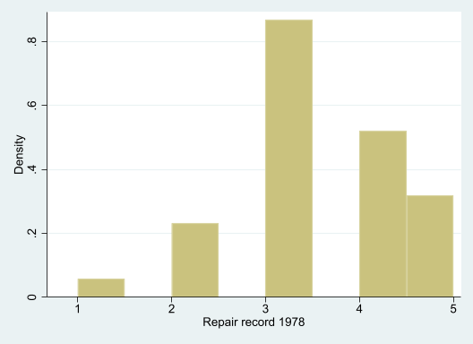

```python
%%stata
sysuse auto, clear
histogram rep78
```

## Call Stata using API functions

In addition to the magic commands, you can also call Stata using the API functions defined in the **stata** module.

- Run a single line or a block of Stata commands
  - run(*cmd* [, *quietly*, *echo*, *inline*])
- Transfer data between Stata and Python
  - nparray_to_data(*arr* [, *prefix*, *force*])
  - pdataframe_to_data(*df* [, *force*])
  - nparray_to_frame(*arr*, *stfr* [, *prefix*, *force*])
  - pdataframe_to_frame(*df*, *stfr* [, *force*])
  - nparray_from_data([*var*, *obs*, *selectvar*, …])
  - pdataframe_from_data([*var*, *obs*, *selectvar*, …])
  - nparray_from_frame(*stfr* [, *var*, *obs*, …])
  - pdataframe_from_frame(*stfr* [, *var*, *obs*, …])
- Access Stata's return results
  - get_return()
  - get_ereturn()
  - get_sreturn()

We use a dataset containing quarterly turkey sales throughout the 1990s to illustrate how to call Stata using API functions.

```python
turksales = pd.read_csv('turksales.csv')
turksales.head()
```

|  | t | sales |
| --- | --- | --- |
| 0 | 1990q1 | 100.000000 |
| 1 | 1990q2 | 97.846031 |
| 2 | 1990q3 | 98.840286 |
| 3 | 1990q4 | 100.827500 |
| 4 | 1991q1 | 98.909805 |

We load the pandas DataFrame into Stata using the **pdataframe_to_data()** function of the **stata** module.

```python
from pystata import stata
stata.pdataframe_to_data(turksales, force=True)
```

Next, we declare the data to be time-series data using the **run()** function.

```python
stata.run('''
generate qdate = quarterly(t, "YQ")
format qdate %tq
tsset qdate, quarterly
''')
```

```
.
. generate qdate = quarterly(t, "YQ")

. format qdate %tq

. tsset qdate, quarterly

Time variable: qdate, 1990q1 to 1999q4
        Delta: 1 quarter

.
```

Afterwards, we fit a autoregressive integrated moving average (ARIMA) model on **sales** using the **arima** command. Then we predict the sale values, storing these values in the variable **sales_pred**.

```python
stata.run('''
arima sales, arima(3, 1, 0)
predict sales_pred, y
''')
```

```
.
. arima sales, arima(3, 1, 0)

(setting optimization to BHHH)
Iteration 0:   log likelihood = -95.623818
Iteration 1:   log likelihood =  -83.15803
Iteration 2:   log likelihood = -78.411534
Iteration 3:   log likelihood = -77.140891
Iteration 4:   log likelihood = -75.668157
(switching optimization to BFGS)
Iteration 5:   log likelihood = -75.617809
Iteration 6:   log likelihood = -75.542463
Iteration 7:   log likelihood = -75.536259
Iteration 8:   log likelihood = -75.535664
Iteration 9:   log likelihood =  -75.53558
Iteration 10:  log likelihood = -75.535576

ARIMA regression

Sample: 1990q2 thru 1999q4                      Number of obs     =         39
                                                Wald chi2(3)      =     125.92
Log likelihood = -75.53558                      Prob > chi2       =     0.0000

------------------------------------------------------------------------------
             |                 OPG
     D.sales | Coefficient  std. err.      z    P>|z|     [95% conf. interval]
-------------+----------------------------------------------------------------
sales        |
       _cons |   .3138001   .0780853     4.02   0.000     .1607558    .4668444
-------------+----------------------------------------------------------------
ARMA         |
          ar |
         L1. |  -.8190625    .087633    -9.35   0.000      -.99082    -.647305
         L2. |  -.8174304   .1006356    -8.12   0.000    -1.014673   -.6201882
         L3. |  -.7738968   .0902345    -8.58   0.000    -.9507531   -.5970404
-------------+----------------------------------------------------------------
      /sigma |   1.608579    .264229     6.09   0.000       1.0907    2.126458
------------------------------------------------------------------------------
Note: The test of the variance against zero is one sided, and the two-sided
      confidence interval is truncated at zero.

. predict sales_pred, y
(1 missing value generated)

.
```

Then we use the **pdataframe_from_data()** function to store the time variable **t**, original sale values **sales**, and the predicted values **sales_pred** in a pandas DataFrame named **stpred**.

```python
import numpy as np
stpred = stata.pdataframe_from_data('t sales sales_pred', missingval=np.nan)
stpred = stpred.set_index("t")
stpred.head()
```

| t | sales | sales_pred |
| --- | --- | --- |
| 1990q1 | 100.000000 | NaN |
| 1990q2 | 97.846031 | 100.313797 |
| 1990q3 | 98.840286 | 98.946854 |
| 1990q4 | 100.827500 | 99.967163 |
| 1991q1 | 98.909805 | 101.124245 |

Next we plot original turkey sale values and the predictions values in Python.

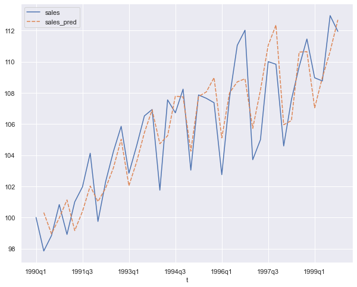

```python
import seaborn as sns
import matplotlib.pyplot as plt
import matplotlib.ticker as ticker

sns.set_theme(style="darkgrid")
fig, ax = plt.subplots(figsize=(10, 8))

lp = sns.lineplot(ax=ax, data=stpred)
lp.xaxis.set_major_locator(ticker.MultipleLocator(6))

plt.show()
```

## Summary

- The **pystata** package provides tight integration bewtween Stata and Python.
- Interact with Stata and Mata from within Python using **stata**, **mata**, and **pystata** magic commands.
- Call Stata from with Python using API functions.

## Additional resources

- Python Integration  
  https://www.stata.com/manuals/ppystataintegration.pdf
- The pystata Python package  
  https://www.stata.com/python/pystata/index.html
- Stata Function Interface (sfi) module  
  https://www.stata.com/python/api17/